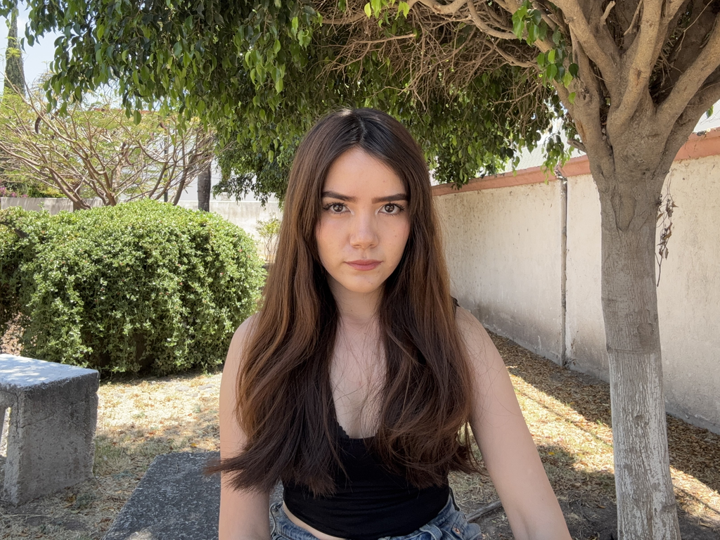

# Mayela Fosado Mendoza

## 🌸 Bio

Hi! I’m Mayela, a microbiologist exploring bioinformatics, data science, and computational biology. I am interested in applying computational approaches to understand biological systems and analyze complex biological data.

I completed my undergraduate thesis at the Instituto de Neurobiología (UNAM), where I performed a metagenomic analysis of the microbiota associated with the body wall of the terrestrial gastropod *Deroceras laeve*. Through this project, I developed experience in bioinformatics workflows, data analysis, and computational tools for biological research.

I am a member of **ISCB RSG-Mexico**, where I contribute to the organization of bioinformatics courses, workshops, symposia, journal clubs, and outreach activities.

Currently, I continue expanding my skills in bioinformatics, computational biology, Python, and data science through research, training programs, and community-driven initiatives.

## Education

**B.Sc. in Microbiology** | Universidad Autónoma de Querétaro (UAQ), Mexico

**Undergraduate Thesis** | Instituto de Neurobiología (INB), UNAM

**Thesis title:** Análisis metagenómico de la microbiota en la pared corporal del gasterópodo *Deroceras laeve*.

## Experience

**Research Intern** | Instituto de Neurobiología, UNAM

Research focused on metagenomics, microbiome analysis, and bioinformatics workflows.

**Council Member** | ISCB RSG-Mexico

Supporting educational initiatives, workshops, symposia, and outreach activities in bioinformatics.

## Repository Contributions

### Thesis Project

- [Microbiota Thesis Pipeline](https://github.com/Mayfm/microbiota-thesis-pipeline)

Bioinformatics workflow developed for my undergraduate thesis, including Bash preprocessing, taxonomic classification, diversity analyses, statistical analyses in R, and data visualization.

### Collaborative Work

- [Workshop Repository](https://github.com/ISCB-RSG-MEXICO/Workshop_Bash2025)

Educational materials and exercises developed for bioinformatics training activities.

## Technical Skills

- Metagenomics & microbiome analysis
- Bioinformatics: Kraken2, phyloseq, KEGG Mapper
- Data analysis in R
- Python for data analysis
- Bash
- Git & GitHub

## Interests

Bioinformatics • Computational Biology • Data Science • Metagenomics • Microbiome Research